# Text Processing from CSV

Aminur Refat Faisal

2026-08-11

# 1. Overview

This notebook walks through a **complete text processing (NLP) pipeline** in R, starting from a CSV file of raw text (for example, articles scraped in the previous web-scraping lecture) and ending with word frequencies, TF–IDF scores, and an optional topic model.

The pipeline has 8 stages:

1. **Read & inspect data** — load the CSV and identify which column holds the text.
2. **Clean text** — strip URLs, punctuation, and inconsistent casing.
3. **Tokenize and remove stopwords** — break text into individual words and discard uninformative ones.
4. *(Optional)* **Stemming / Lemmatization** — reduce words to a common root form.
5. **Word frequency + visualization** — bar chart and word cloud of the most common terms.
6. **TF–IDF and Document-Term Matrix (DTM)** — measure how important each word is to each document.
7. *(Optional)* **Topic modeling (LDA)** — automatically discover latent themes across documents.
8. **Save outputs** — write cleaned data and results to disk for reuse.

> **Why this matters:** Nearly every text-mining or NLP task — sentiment analysis, topic modeling, document classification, information retrieval — begins with this same clean → tokenize → weight pipeline. Understanding each stage here will let you adapt it to almost any text dataset.

# 2. Packages

We rely on several packages, each handling a different part of the pipeline:

| Package | Purpose |
| --- | --- |
| `tidyverse` | Core data wrangling and plotting (`dplyr`, `ggplot2`, `purrr`, etc.) |
| `readr` | Fast, UTF-8-safe CSV reading (`read_csv`) |
| `stringr` | Regular-expression-based string cleaning |
| `janitor` | Utility functions for cleaning messy data/column names |
| `tidytext` | Tokenization, stopword removal, TF–IDF, and DTM conversion in a tidy (one-row-per-token) format |
| `SnowballC` | Implements the Porter stemming algorithm |
| `wordcloud` | Generates word cloud visualizations |
| `topicmodels` | Fits Latent Dirichlet Allocation (LDA) topic models |

> **A note on the `এ`-style escapes you may see in the R console:** This is a *display* limitation of R’s console on Windows, not corrupted data. The Windows R console (and Rgui/Rterm) renders text using your system’s native codepage, and falls back to `<U+xxxx>` escapes for any character outside that codepage – Bengali glyphs included. It does **not** mean the underlying string is broken. Two ways to fix the *display*:
> 1. **System-level fix (recommended, permanent):** Windows Settings → Region → Administrative language settings → “Change system locale” → check **“Beta: Use Unicode UTF-8 for worldwide language support”**, then reboot. This makes R’s console codepage UTF-8, so Bengali (and any script) prints correctly everywhere – console, `View()`, `cat()`, etc.
> 2. **Per-session workaround:** knit to HTML (as this document already does) rather than relying on console `print()`/`cat()` output. Knitted HTML is written as real UTF-8 bytes and rendered by your browser, which is not subject to the console’s codepage limitation – so Bengali should display correctly in the knitted document even without the system-level fix above.

```r
# List of required packages
packages <- c("tidyverse", "readr", "stringr", "janitor",
            "tidytext", "SnowballC", "wordcloud", "topicmodels")

# Check which packages are already installed on this machine
installed_packages <- rownames(installed.packages())

for (pkg in packages) {
  # Install only if missing
  if (!(pkg %in% installed_packages)) {
    install.packages(pkg, dependencies = TRUE)
  }
  # Load the package into the current session
  library(pkg, character.only = TRUE)
}
```

# 3. Read CSV (UTF-8 Safe) and Identify the Text Column

```r
# --------------------------------------------------------------------
# IMPORTANT: Update this path to point to YOUR CSV file before running.
# This example uses a Windows-style absolute path — replace it with the
# actual location of your file (e.g., a file produced by the web-scraping
# lecture, such as "prothomalo_articles_....csv" ).
# --------------------------------------------------------------------
csv_path <- "D:\\Downloads\\TheDailyStar_Articles_2026-08-11_20-23-29.csv"

# Name of the column that holds the text we want to analyze.
# Change this if your CSV uses a different column name (e.g., "article",
# "text", "body").
TEXT_COL <- "content"

# read_csv() with an explicit UTF-8 locale ensures non-Latin scripts
# (e.g., Bengali) are read correctly rather than being garbled.
raw <- read_csv(csv_path, locale = locale(encoding = "UTF-8"), show_col_types = FALSE)

# --------------------------------------------------------------------
# Safety net: if TEXT_COL doesn't exist in this particular CSV (e.g., you
# reused this script on a different file), automatically guess which
# column is most likely to contain the main text — by picking the
# character/factor column with the LONGEST average string length.
# --------------------------------------------------------------------
if (!TEXT_COL %in% names(raw)) {
  candidates <- names(raw)[map_lgl(raw, ~ is.character(.x) || is.factor(.x))]
  TEXT_COL <- candidates[which.max(sapply(raw[candidates],
                                          function(x) mean(nchar(as.character(x)), na.rm = TRUE)))]
  message("Guessed text column: ", TEXT_COL)
}

# Build our working data frame:
# - doc_id: a unique numeric ID for each row (each document), used later
#   to link tokens back to their source document (needed for TF-IDF/DTM).
# - text: a plain character-vector copy of the chosen text column.
df <- raw %>%
  mutate(doc_id = row_number(),
         text   = as.character(.data[[TEXT_COL]])) %>%
  select(doc_id, everything())

# --------------------------------------------------------------------
# IMPORTANT (fixed): we do NOT re-encode here. read_csv() above already
# decoded the file correctly using locale(encoding = "UTF-8"), so df$text
# is already valid UTF-8. Previously this step called:
#     iconv(df$text, from = "", to = "UTF-8")
# `from = ""` tells iconv to treat the (already-decoded) UTF-8 string as
# if it were encoded in your SYSTEM's native locale (on Windows this is
# almost never UTF-8 -- it's typically a codepage like CP1252). That
# double-encodes valid UTF-8 bytes and is exactly what produces garbled
# output like "à¦Ÿà¦¬à¦²" for Bengali text. We simply drop that step.
#
# Instead, we just VALIDATE that the text is well-formed UTF-8:
Encoding(df$text) <- "UTF-8"  # tag encoding explicitly (no byte re-encoding)
n_invalid <- sum(!validUTF8(df$text))
if (n_invalid > 0) {
  warning(n_invalid, " row(s) contain invalid UTF-8 bytes. ",
          "This usually means the SOURCE CSV itself was not saved as UTF-8. ",
          "Re-check the encoding of the scraper/export step that produced it.")
}

# ---- Basic sanity checks before proceeding ----
cat("Rows:", nrow(df), "\n")
```

```
## Rows: 55
```

```r
cat("NAs in text:", sum(is.na(df$text)), "\n")
```

```
## NAs in text: 10
```

```r
cat("Rows with invalid UTF-8:", n_invalid, "\n")
```

```
## Rows with invalid UTF-8: 0
```

```r
# Data cleaning at the ROW level (before we clean the text itself):
# - Remove rows where text is NA
# - Collapse repeated whitespace (str_squish)
# - Remove rows that are now blank
# - Remove exact duplicate documents (e.g., the same article scraped twice)
df <- df %>%
  filter(!is.na(text)) %>%
  mutate(text = str_squish(text)) %>%
  filter(text != "") %>%
  distinct(text, .keep_all = TRUE)

# Show a sample so we can visually confirm the data loaded correctly
df %>% select(doc_id, !!TEXT_COL := text) %>% head(5)
```

```
## # A tibble: 5 × 2
##   doc_id content
##    <int> <chr>
## 1      1 Not just political wisdom, economic knowledge is also needed: Mahfuz A…
## 2      2 Growing unease over Hasina: A new Dhaka-Delhi equation
## 3      3 SSC pass rate falls to 62.25%; GPA-5 holders also decline
## 4      4 Trump took secret flight out of Turkey due to Iran threat, the Washing…
## 5      5 Hasina will get full security if she returns to Bangladesh: Zahed
```

# 4. Clean Text

Raw text almost always contains “noise” that isn’t useful for analysis — URLs, social-media handles, punctuation, and inconsistent capitalization. This step standardizes the text before we tokenize it.

Specifically, `clean_text()` will:

- **Remove URLs** (e.g., `https://...`, `www...`)
- **Remove @mentions and #hashtags** (relevant if your data came from social media)
- **Keep only letters, numbers, combining marks, spaces, and apostrophes** — everything else (punctuation, symbols, emojis) is replaced with a space. The `\\p{L}` (any Unicode *letter*), `\\p{N}` (any Unicode *number*), and `\\p{M}` (any Unicode *combining mark*) character classes are used instead of plain `[a-zA-Z]` so that **non-Latin scripts such as Bengali, Arabic, or Devanagari are preserved correctly**. `\\p{M}` matters a lot for scripts like Bengali/Devanagari: dependent vowel signs and the virama/হসন্ত that forms consonant conjuncts are Unicode *Marks*, not *Letters* — dropping `\\p{M}` silently shatters words like “দীর্ঘ” into “দ র ঘ”.
- **Lowercase everything** — so that “Research” and “research” are treated as the same word.
- **Trim/squish extra whitespace** left behind by the replacements above.

```r
clean_text <- function(x) {
  x %>%
    str_replace_all("https?://\\S+|www\\.[^\\s]+", " ") %>%  # remove URLs
    str_replace_all("@\\w+|#\\w+", " ") %>%                 # remove mentions/hashtags
    # Keep letters, numbers, COMBINING MARKS, spaces, and apostrophes.
    # \\p{M} (Unicode "Mark" category) is essential for Bengali and other
    # Indic scripts: dependent vowel signs (কার, e.g. া ি ী ু ূ ে ো) and
    # the virama/হসন্ত (্, which joins consonants into conjuncts) are Marks,
    # NOT Letters. Without \\p{M} here, this step strips every vowel sign
    # and virama out of Bengali text and replaces them with a space --
    # which is what turns "দীর্ঘ" into "দ র ঘ": the consonants survive
    # (they ARE \\p{L}), but the marks holding them together are deleted.
    str_replace_all("[^\\p{L}\\p{N}\\p{M}\\s']", " ") %>%
    str_to_lower() %>%                                       # lowercase (no-op for Bengali; harmless)
    str_squish()                                             # collapse repeated whitespace
}

# Apply the cleaning function and store the result in a new column,
# keeping the original "text" column intact for reference/auditing.
df <- df %>% mutate(text_clean = clean_text(text))

# Compare original vs. cleaned text side-by-side
df %>% select(doc_id, text, text_clean) %>% head(5)
```

```
## # A tibble: 5 × 3
##   doc_id text                                                         text_clean
##    <int> <chr>                                                        <chr>
## 1      1 Not just political wisdom, economic knowledge is also neede… not just …
## 2      2 Growing unease over Hasina: A new Dhaka-Delhi equation       growing u…
## 3      3 SSC pass rate falls to 62.25%; GPA-5 holders also decline    ssc pass …
## 4      4 Trump took secret flight out of Turkey due to Iran threat, … trump too…
## 5      5 Hasina will get full security if she returns to Bangladesh:… hasina wi…
```

> **Note:** This is a *general-purpose* English-oriented cleaner. If you’re working primarily with Bengali or other non-Latin text, consider whether lowercasing and Latin-specific stopword lists (Section 5) still make sense — you may need a language-specific stopword list instead.

# 5. Tokenize and Remove Stopwords

**Tokenization** breaks each document’s text into individual words (“tokens”) — one row per word, tagged with which document it came from. This is the standard “tidy text” format used by the `tidytext` package.

**Stopwords** are extremely common words (*the, is, and, a, …*) that carry little topical meaning and are usually removed before frequency analysis, since otherwise they would dominate every word-count list.

```r
data(stop_words)  # loads tidytext's built-in English stopword list

tokens <- df %>%
  # unnest_tokens() splits the "text_clean" column into one word per row,
  # automatically preserving doc_id so we know which document each word
  # came from.
  unnest_tokens(word, text_clean, token = "words") %>%
  # anti_join() removes any row whose "word" matches a stopword —
  # i.e., it keeps only words that are NOT in the stop_words list.
  anti_join(stop_words, by = "word") %>%
  # Drop very short tokens (1-2 characters), which are often leftover
  # noise (single letters, initials) rather than meaningful words.
  filter(nchar(word) >= 3)

tokens %>% head(10)
```

```
## # A tibble: 10 × 6
##    doc_id content                                        title link  text  word
##     <int> <chr>                                          <chr> <chr> <chr> <chr>
##  1      1 Not just political wisdom, economic knowledge… "Cop… http… Not … poli…
##  2      1 Not just political wisdom, economic knowledge… "Cop… http… Not … wisd…
##  3      1 Not just political wisdom, economic knowledge… "Cop… http… Not … econ…
##  4      1 Not just political wisdom, economic knowledge… "Cop… http… Not … know…
##  5      1 Not just political wisdom, economic knowledge… "Cop… http… Not … mahf…
##  6      1 Not just political wisdom, economic knowledge… "Cop… http… Not … anam
##  7      2 Growing unease over Hasina: A new Dhaka-Delhi… "Cop… http… Grow… grow…
##  8      2 Growing unease over Hasina: A new Dhaka-Delhi… "Cop… http… Grow… unea…
##  9      2 Growing unease over Hasina: A new Dhaka-Delhi… "Cop… http… Grow… hasi…
## 10      2 Growing unease over Hasina: A new Dhaka-Delhi… "Cop… http… Grow… dhaka
```

> **Bengali-specific note:** `stop_words` (Section 5) and `SnowballC::wordStem(..., language = "en")` (Section 6) are both English-only resources. Now that the encoding bug is fixed and Bengali tokens will reach this stage intact, be aware that neither step will remove Bengali stopwords or stem Bengali words – they will simply pass through unchanged. For a Bengali corpus you’ll want a Bengali stopword list (e.g. build one from a published list or the `stopwords` package’s `stopwords("bn", source = "stopwords-iso")`) and skip or replace the stemming step, since Bengali morphology isn’t handled by the Porter stemmer.

> **Adding custom, domain-specific stopwords:** The built-in list is general-purpose English. For news-article text, you may want to remove additional words that are common but uninformative in *this specific domain* (e.g., “said”, “also”, “reported”). Do this with a second `anti_join()`:

> ```r
> my_sw <- tibble(word = c("said", "also", "new", "one"))
> tokens <- tokens %>% anti_join(my_sw, by = "word")
> ```

# 6. (Optional) Stemming or Lemmatization

Words like *“run”, “running”, “runs”* are different surface forms of the same underlying concept. Before counting word frequencies, it’s common to collapse these variants into a single form:

- **Stemming** — a fast, rule-based approach that chops off common suffixes (e.g., *running → run*, *studies → studi*). It’s quick but sometimes produces non-words (as in the “studi” example).
- **Lemmatization** — a more linguistically accurate approach that maps words to their dictionary base form using vocabulary and grammar rules (e.g., *better → good*). It’s more accurate but slower and requires an additional package (`textstem`), not used here by default.

This tutorial uses **stemming** via the Porter algorithm (`SnowballC`), since it is fast and sufficient for word-frequency and TF–IDF analysis.

```r
tokens <- tokens %>%
  mutate(stem = SnowballC::wordStem(word, language = "en"))

# Compare the original word against its stem
tokens %>% select(doc_id, word, stem) %>% head(10)
```

```
## # A tibble: 10 × 3
##    doc_id word      stem
##     <int> <chr>     <chr>
##  1      1 political polit
##  2      1 wisdom    wisdom
##  3      1 economic  econom
##  4      1 knowledge knowledg
##  5      1 mahfuz    mahfuz
##  6      1 anam      anam
##  7      2 growing   grow
##  8      2 unease    uneas
##  9      2 hasina    hasina
## 10      2 dhaka     dhaka
```

> **Switching to lemmatization instead:** install and load `textstem`, then replace the `mutate()` above with:

> ```r
> tokens <- tokens %>% mutate(stem = textstem::lemmatize_words(word))
> ```

# 7. Word Frequency

Now that we have clean, stemmed tokens, we can count how often each word (stem) appears across the *entire* corpus (all documents combined).

```r
word_freq <- tokens %>%
  count(stem, sort = TRUE)   # count() tallies occurrences; sort = TRUE orders by frequency

head(word_freq, 20)
```

```
## # A tibble: 20 × 2
##    stem           n
##    <chr>      <int>
##  1 bangladesh     9
##  2 dhaka          6
##  3 cup            3
##  4 econom         3
##  5 futur          3
##  6 grow           3
##  7 myanmar        3
##  8 readi          3
##  9 world          3
## 10 begum          2
## 11 china          2
## 12 corridor       2
## 13 cost           2
## 14 day            2
## 15 extort         2
## 16 famili         2
## 17 food           2
## 18 hasina         2
## 19 health         2
## 20 hidden         2
```

A simple horizontal bar chart makes the most frequent terms easy to scan.

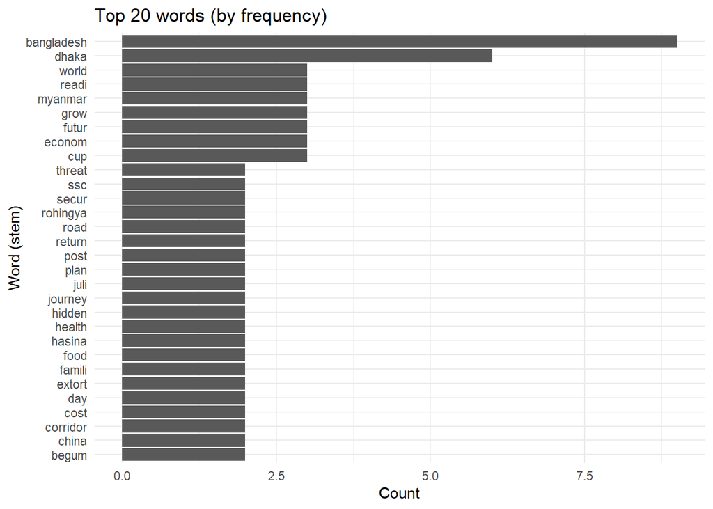

```r
top_n <- 20

p <- word_freq %>%
  slice_max(n, n = top_n) %>%                       # keep only the top 20 rows by count
  ggplot(aes(x = reorder(stem, n), y = n)) +         # reorder() sorts bars by frequency
  geom_col() +                                       # bar chart
  coord_flip() +                                     # horizontal bars (easier to read word labels)
  labs(title = paste("Top", top_n, "words (by frequency)"),
       x = "Word (stem)", y = "Count") +
  theme_minimal()
p
```

```r
# Save the plot as a PNG file for use in reports/presentations
ggplot2::ggsave("top_words_bar.png", p, width = 7, height = 5, dpi = 300)
```

## 7.2 Word Cloud

A word cloud is a quick, intuitive (though not very precise) visualization where word size scales with frequency.

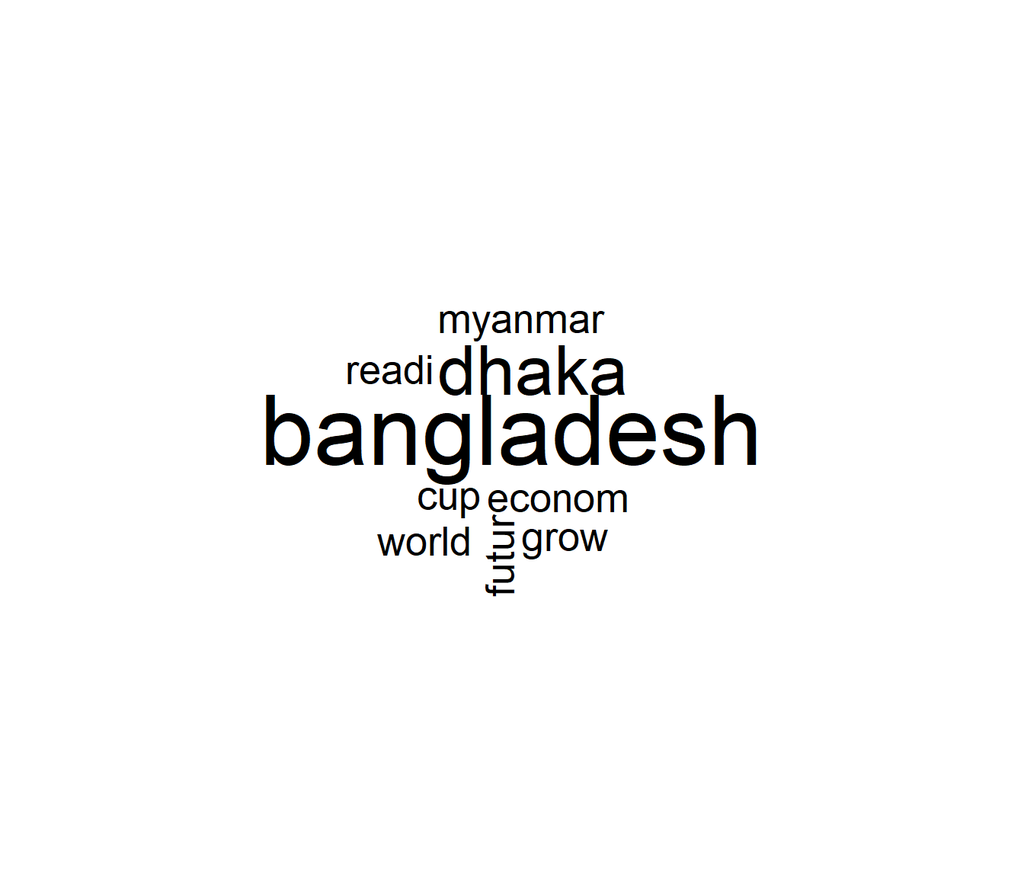

```r
par(mar = c(1,1,1,1))  # shrink plot margins — prevents "figure margins too large" errors

# Filter out words that appear only once, since they add visual clutter
# without conveying much information
wc_df <- word_freq %>% filter(n > 1)

suppressWarnings(
  wordcloud(words = wc_df$stem, freq = wc_df$n, max.words = 200, random.order = FALSE)
)
```

```r
# Save the word cloud to a PNG file (base R graphics device workflow:
# open a device, draw the plot, then close the device)
png("wordcloud.png", width = 1200, height = 900, res = 150)
par(mar = c(1,1,1,1))
wordcloud(words = wc_df$stem, freq = wc_df$n, max.words = 200, random.order = FALSE)
dev.off()
```

> **Caution:** Word clouds are visually appealing but statistically weak — they’re good for quick, informal summaries or presentations, but should not be used as evidence in formal research analysis. Prefer the bar chart or TF–IDF table (Section 8) for anything you plan to report rigorously.

# 8. TF–IDF and Document-Term Matrix (DTM)

**Raw word counts** (Section 7) tell you what’s frequent *overall*, but not what’s *distinctive* about any single document. A word like “government” might appear in every news article and therefore isn’t useful for telling articles apart.

**TF–IDF (Term Frequency–Inverse Document Frequency)** solves this: it upweights words that are frequent *within* a specific document but rare *across* the whole corpus — i.e., words that are distinctive of that document.

- **TF (Term Frequency):** how often a word appears in *this* document.
- **IDF (Inverse Document Frequency):** how rare that word is across *all* documents (words appearing in every document get a low, near-zero IDF).
- **TF–IDF = TF × IDF:** high when a word is common in one document but uncommon elsewhere.

```r
tfidf <- tokens %>%
  count(doc_id, stem, sort = FALSE) %>%                     # word counts PER document
  bind_tf_idf(term = stem, document = doc_id, n = n) %>%    # adds tf, idf, and tf_idf columns
  arrange(desc(tf_idf))                                      # sort by most distinctive terms first

head(tfidf, 15)
```

```
## # A tibble: 15 × 6
##    doc_id stem          n    tf   idf tf_idf
##     <int> <chr>     <int> <dbl> <dbl>  <dbl>
##  1     44 conveni       1 0.5    3.81  1.90
##  2     44 price         1 0.5    3.81  1.90
##  3     20 fear          1 0.333  3.81  1.27
##  4     20 pregnanc      1 0.333  3.81  1.27
##  5     20 separ         1 0.333  3.81  1.27
##  6     14 danger        1 0.25   3.81  0.952
##  7     14 hotter        1 0.25   3.81  0.952
##  8     15 system        1 0.25   3.81  0.952
##  9     15 transform     1 0.25   3.81  0.952
## 10     22 cepa          1 0.25   3.81  0.952
## 11     22 korea         1 0.25   3.81  0.952
## 12     22 south         1 0.25   3.81  0.952
## 13     26 potenti       1 0.25   3.81  0.952
## 14     26 result        1 0.25   3.81  0.952
## 15     26 true          1 0.25   3.81  0.952
```

A **Document-Term Matrix (DTM)** is the standard input format required by most text-mining and machine-learning models (including topic models in Section 9). It’s a sparse matrix where rows = documents, columns = terms, and cell values = a weight (here, TF–IDF).

```r
# cast_dtm() converts our tidy (long-format) tfidf table into a wide,
# sparse Document-Term Matrix
dtm_tfidf <- tfidf %>%
  cast_dtm(document = doc_id, term = stem, value = tf_idf)

dtm_tfidf
```

```
## <<DocumentTermMatrix (documents: 45, terms: 221)>>
## Non-/sparse entries: 268/9677
## Sparsity           : 97%
## Maximal term length: 11
## Weighting          : term frequency (tf)
```

> **Using raw counts instead of TF–IDF weighting:** some models (e.g., standard LDA) expect raw counts rather than TF–IDF values:

> ```r
> dtm_counts <- tokens %>% count(doc_id, stem) %>% cast_dtm(doc_id, stem, n)
> ```

# 9. (Optional) Quick Topic Modeling (LDA)

**Latent Dirichlet Allocation (LDA)** is an unsupervised algorithm that discovers latent “topics” — clusters of words that tend to co-occur — across a collection of documents, without requiring any labeled data.

This chunk is set to `eval=FALSE` by default (it will **not** run automatically when you knit the document) because: - LDA typically expects a **raw-count DTM**, not a TF–IDF-weighted one. - Choosing the right number of topics (`k`) requires experimentation.

> This is a minimal illustration only. For serious use: tune `k` (number of topics), try multiple random seeds, and evaluate model quality using coherence or perplexity metrics rather than eyeballing the output.

```r
k <- 3  # number of topics to discover — this is a hyperparameter you must choose

lda_model <- LDA(dtm_tfidf, k = k, control = list(seed = 1234))  # seed = reproducibility

# tidy() converts the model's internal matrices into a tidy data frame.
# matrix = "beta" gives the per-topic word probabilities.
topic_terms <- tidy(lda_model, matrix = "beta") %>%
  group_by(topic) %>%
  slice_max(beta, n = 10) %>%   # top 10 most probable words per topic
  ungroup()

topic_terms
```

# 10. Save Outputs

Finally, we persist the key intermediate and final results to disk, so they can be reused in later analyses (e.g., an NLP or ML modeling notebook) without re-running the entire pipeline from scratch.

```r
# NOTE: we use write_excel_csv() instead of write_csv(). Both write valid
# UTF-8, but write_excel_csv() also prepends a UTF-8 byte-order-mark (BOM).
# Windows/Excel do NOT assume UTF-8 for a plain .csv with no BOM -- they
# fall back to the system codepage, which is what turns correctly-saved
# Bengali text into "à¦Ÿà¦¬à¦²"-style garbage the moment you open the file.
# The BOM tells Excel (and most Windows text editors) "this file is UTF-8",
# so it displays correctly. If you'll only ever re-read these files with
# read_csv() in R, plain write_csv() is fine either way -- the BOM mainly
# matters for Excel/Notepad-style viewers.
write_excel_csv(df,        "cleaned_text.csv")   # cleaned documents (one row per document)
write_excel_csv(word_freq, "top_words.csv")      # overall word frequency table
write_excel_csv(tfidf,     "tfidf_by_doc.csv")   # per-document TF-IDF scores

cat("Saved files: cleaned_text.csv, top_words.csv, tfidf_by_doc.csv, top_words_bar.png, wordcloud.png\n")
```

```
## Saved files: cleaned_text.csv, top_words.csv, tfidf_by_doc.csv, top_words_bar.png, wordcloud.png
```

# 11. Summary

In this notebook, you learned how to:

- Load a CSV of text data safely with correct UTF-8 encoding.
- Clean raw text using regular expressions while preserving non-Latin scripts.
- Tokenize text and remove both general and domain-specific stopwords.
- Reduce words to a common root using stemming (and how to switch to lemmatization).
- Visualize word frequency using a bar chart and word cloud.
- Compute TF–IDF scores and build a Document-Term Matrix.
- Fit a basic LDA topic model to discover latent themes.
- Export all key outputs for reuse in downstream analysis.

**Next steps to try on your own:**

- Combine this pipeline with the Prothom Alo scraper (Lecture 6) to build an end-to-end scrape → clean → analyze workflow.
- Experiment with different values of `k` in the LDA model and compare the resulting topics.
- Try a sentiment analysis extension using `tidytext::get_sentiments()`.